# Time Series Regression

Ankit

1/11/2019

In time series regression model, we will predict our forecast variable y using independent(regressor) variable x. To do that we will first assume that y and x linearly related to each other.

## Simple Linear Regression :-

Simple linear regression tries to forecast the value of forecast variable y using just one single predictor variable. In other words, we are trying to find the linear relationship between y and x obviously assuming there is a linear relationship exist.

$$y_t = b_o + b_1 x + e_t$$

where $b_o$ represents the intercept of the line or predicted value of y for x = 0. and $b_1$ represents the slope of the line or the average predicted change in y results from a unit increase in x.

For e.g.

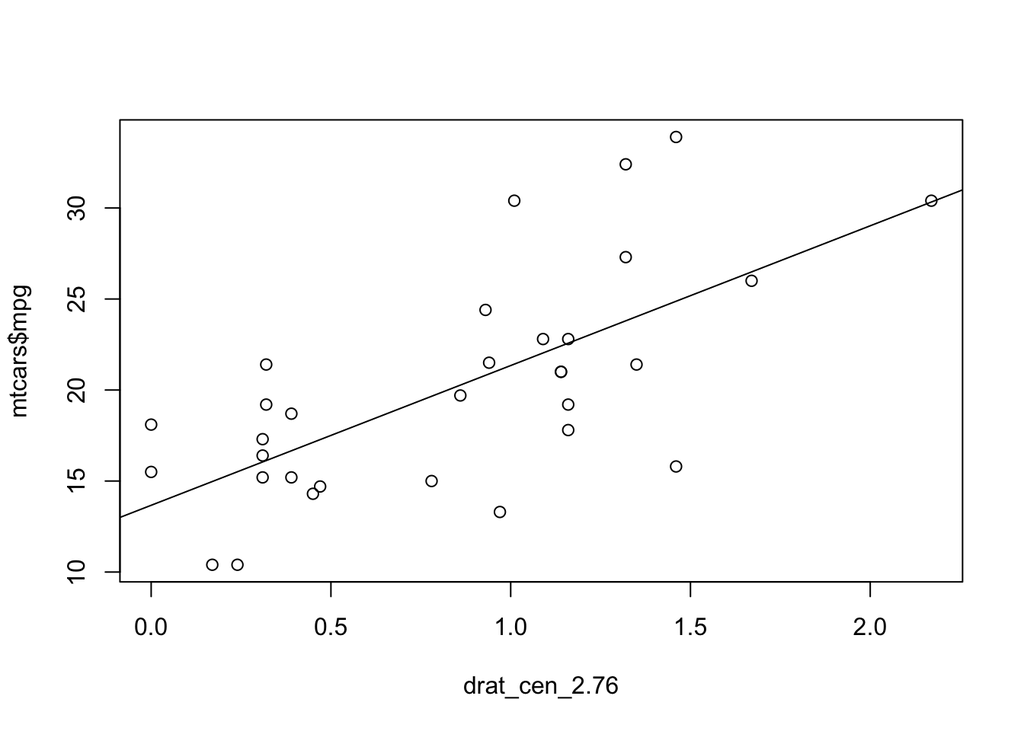

```r
drat_cen_2.76 = mtcars$drat - 2.76 # we are centering the variable so that we can have a zero on the x-axis.
plot(drat_cen_2.76, mtcars$mpg)
abline(lm(mtcars$mpg~drat_cen_2.76))
```

In the above fitted straight line, $b_o$ is the value of mpg when the drat is 0 which is 13.667. $b_1$ is the rate at which the straight is increasing. $e_t$ is the vertical distance between the straight line and the data points. $e_t$ captures anything that effects $y_t$ other than $x_t$.

One way to look at the relationship between the forecast variable and predictor variable is to visualize them in the same plot.

```r
library(fpp2)
```

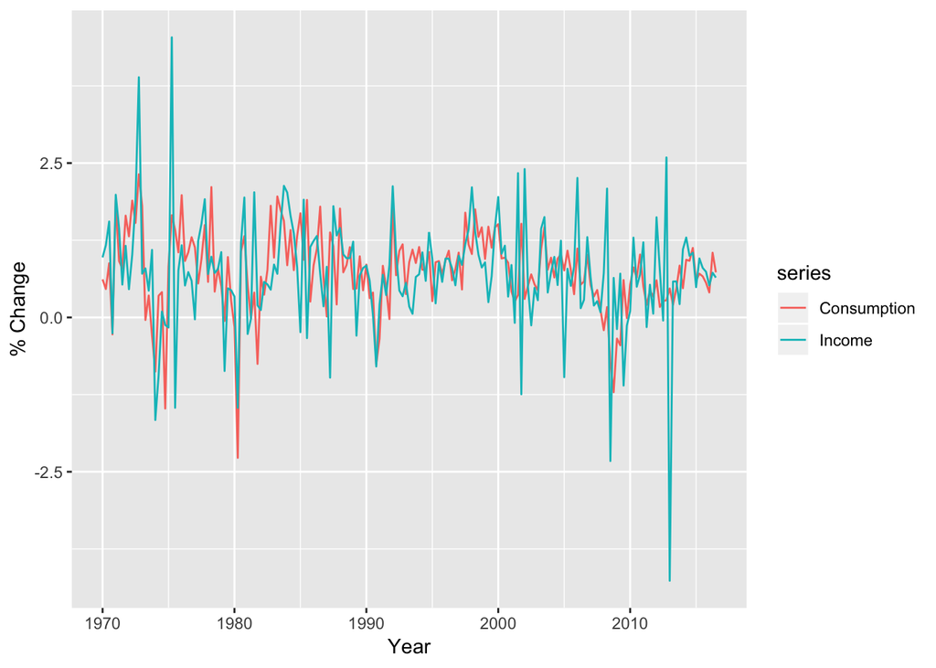

```r
autoplot(uschange[,c("Consumption","Income")]) +
  ylab("% Change") + xlab("Year")
```

We will now fit a linear model between consumption and income and plot it.

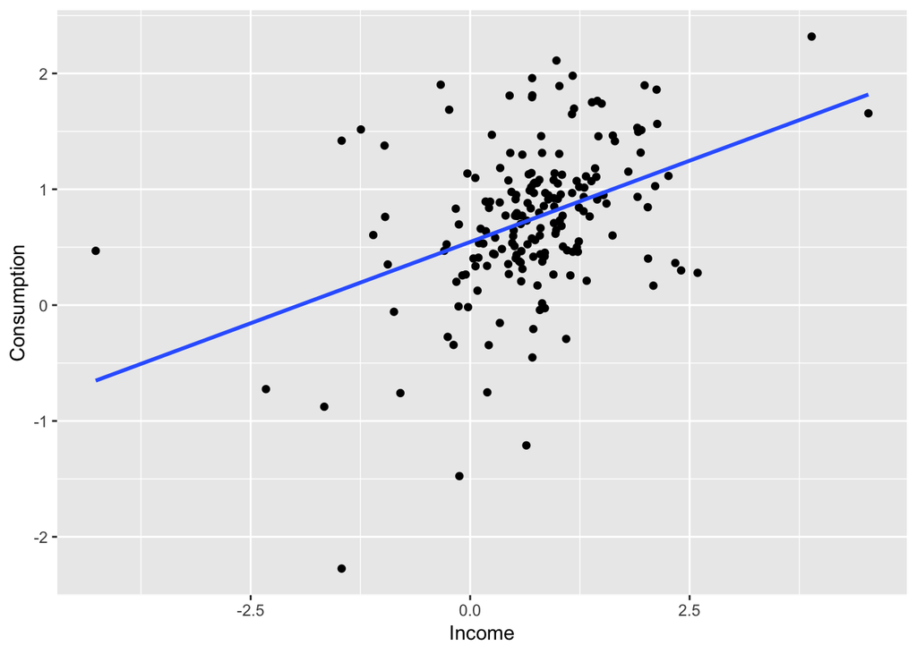

```r
uschange %>%
  as.data.frame() %>%
  ggplot(aes(x = Income, y = Consumption)) +
  ylab("Consumption") +
  xlab("Income") +
  geom_point() +
  geom_smooth(method = "lm", se = FALSE)
```

```r
tslm(Consumption ~ Income, data = uschange)
```

```
##
## Call:
## tslm(formula = Consumption ~ Income, data = uschange)
##
## Coefficients:
## (Intercept)       Income
##      0.5451       0.2806
```

The sign of the $b_1$ tells us if the relationship is positive or negetive which is in this case is positive. For 1 percentage point increase in income, predicted average percentage increase in consumption is 0.2806. 0.5451 is the change in consumption when the change in income is zero. (This doesn’t always make sense only when x=0 is meaningful).

/////////////////////////////////\\\\\\\\\\\\\\\\\\\\\\\\  
## Multiple Linear Regression

/////////////////////////////////\\\\\\\\\\\\\\\\\\\\\\\\  
When we have more than one predictors, the model is called multiple regression model.

$$y_t = b_o +b_1x_{1,t} + b_2x_{2,t} +......+ b_kx_{k,t} + e_t$$
Each of the effects are numerical. The coefficients in the model measures the effect of each predictors after taking into account the effects of all the predictors in the model. Hence they measure the marginal effects of the predictor variable.

Now we will add more features in the above model.

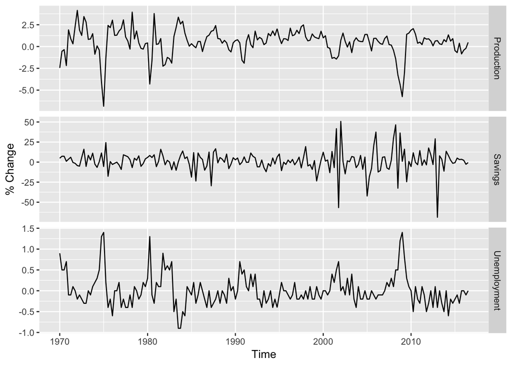

```r
autoplot(uschange[,c("Production","Savings","Unemployment")], facets = TRUE) +
  ylab("% Change")
```

We can see the relationship of the variables.

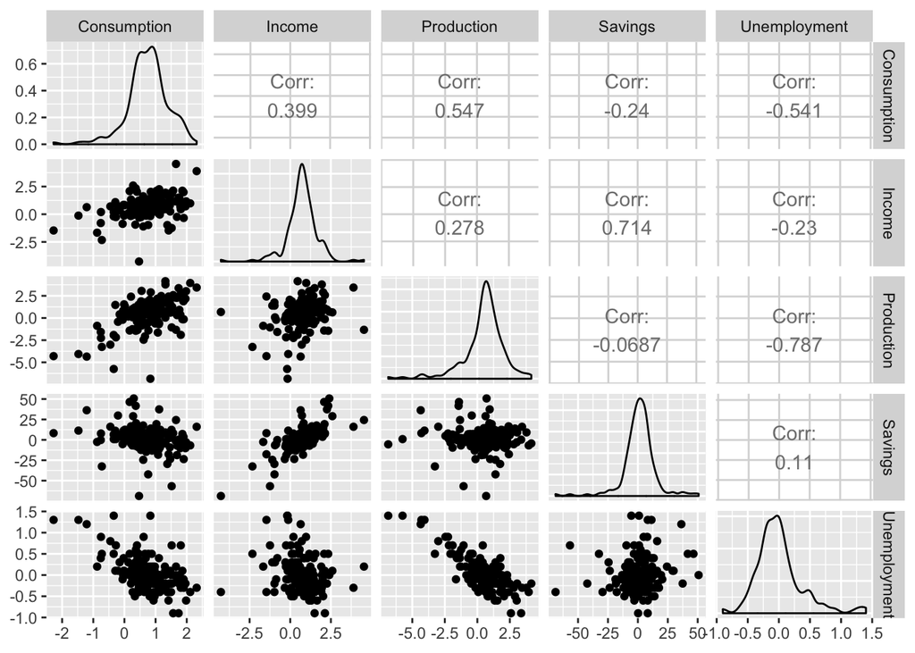

```r
uschange %>%
  as.data.frame() %>%
  GGally::ggpairs()
```

The scatterplot shows the positive relationship between consumption and income, production and negetive relationship with savings and unemployement.

**Assumptions of the linear model:-** 1.Erros have zero mean. 2.Errors are not autocorrelated. This means there is more information in the data that can be exploited using a linear model. 3. Errors are unrelated to predictor variables, otherwise there would be more information that should be included in the systematic part of the model.

**Other assumption :-** Errors are normally distributed with constant variance. This is useful in producing prediction intervals. Each predictor is not a random variable.

### Least Square Estimate :-

The values of b’s is estimated using the least square principle. We choose the values of $b_o, b_1,....,b_k$ that minimise
$$\sum_{t=1}^{T}e_{t}^{2} = \sum_{t=1}^{T} (y_t - b_o - b_1x_{1,t} - b_2x_{2,t} - .... -b_kx_{k,t})^2.$$

This is called least squares estimation because it gives the least value for the sum of squared errors.

Now we are fitting a multiple regression model for the same data using all the available variables.

```r
fit_cons = tslm(Consumption ~ Income + Production + Unemployment + Savings, data = uschange)
summary(fit_cons)
```

```
##
## Call:
## tslm(formula = Consumption ~ Income + Production + Unemployment +
##     Savings, data = uschange)
##
## Residuals:
##      Min       1Q   Median       3Q      Max
## -0.88296 -0.17638 -0.03679  0.15251  1.20553
##
## Coefficients:
##              Estimate Std. Error t value Pr(>|t|)
## (Intercept)   0.26729    0.03721   7.184 1.68e-11 ***
## Income        0.71449    0.04219  16.934  < 2e-16 ***
## Production    0.04589    0.02588   1.773   0.0778 .
## Unemployment -0.20477    0.10550  -1.941   0.0538 .
## Savings      -0.04527    0.00278 -16.287  < 2e-16 ***
## ---
## Signif. codes:  0 '***' 0.001 '**' 0.01 '*' 0.05 '.' 0.1 ' ' 1
##
## Residual standard error: 0.3286 on 182 degrees of freedom
## Multiple R-squared:  0.754,  Adjusted R-squared:  0.7486
## F-statistic: 139.5 on 4 and 182 DF,  p-value: < 2.2e-16
```

**Estimate :-** value of b’s in the regression equation. **Std.Error :-** The standard error gives a measure of the uncertainty in the estimated ‘b’ coefficient. The standard deviation which would be obtained from repeatedly estimating the ‘b’ coefficients on similar data sets.

The last two columns are useful when you’re studying the effect of predictors. **t value :-** The “t value” is the ratio of an estimated ‘b’ coefficient to its standard error. **Pr(>|t|) :-** the probability of the estimated ‘b’ coefficient being as large as it is if there was no real relationship between consumption and the corresponding predictor.

Now we will plot the estimated and actual value together.

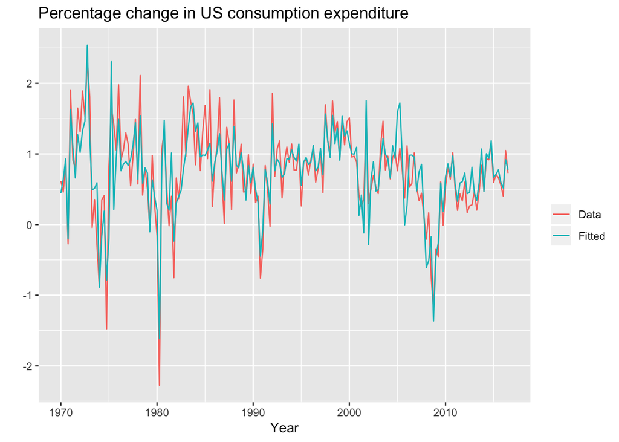

```r
autoplot(uschange[,"Consumption"],series = "Data") +
  autolayer(fitted(fit_cons), series = "Fitted") +
  xlab("Year") + ylab("") +
  ggtitle("Percentage change in US consumption expenditure") +
  guides(colour = guide_legend(title = " "))
```

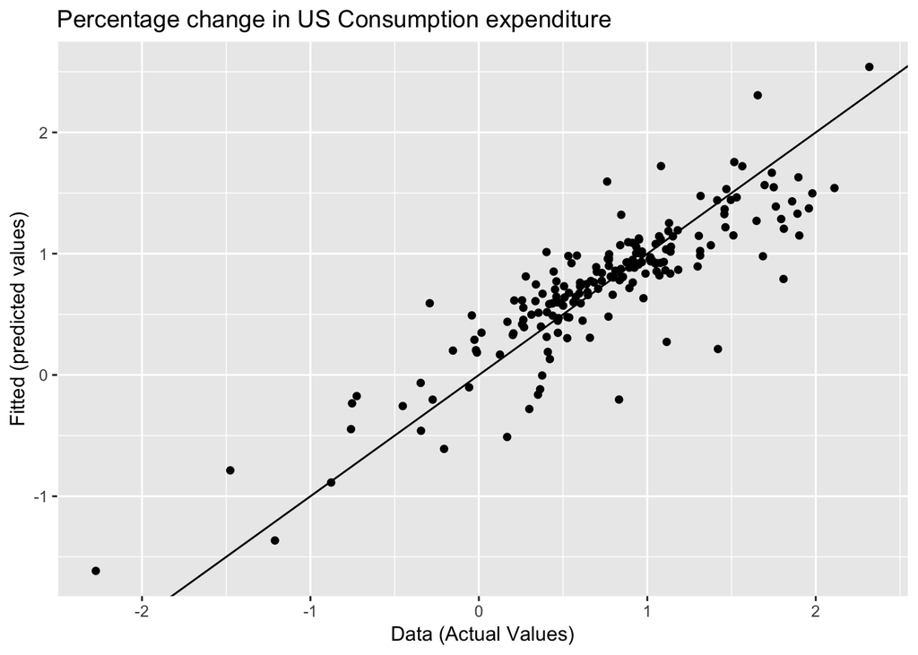

```r
cbind(Data = uschange[,"Consumption"],Fitted = fitted(fit_cons)) %>%
  as.data.frame() %>%
  ggplot(aes(x = Data, y = Fitted)) +
  geom_point() +
  xlab("Data (Actual Values)") +
  ylab("Fitted (predicted values)") +
  ggtitle("Percentage change in US Consumption expenditure") +
  geom_abline(intercept = 0, slope = 1)
```

**Goodness of Fit :-** One way to check how well model fits the data is to calculate coefficient of determination ($R^2$).
$$R^2 = \frac{\sum((\hat{y}_t) - (\overline{y}_t))^2}{\sum(y_t - (\overline{y}_t))^2},$$
This formula above reflects the proportion of variation in the forecast variable that is explained by the regression model.

In case of simple linear regression, $R^2$ is equivalent to the square of the correlation of y and x(provided an intercept has been included).

$R^2$ lies between 0 to 1. Closer to 1 means that model fits the data well. In the above fitted model, the value is 0.754. We can find it below the coefficient table.

**Limitation of $R^2$ :-** 1. $R^2$ can never decrease on adding a predictor variable to the model. This usually leads to assuming that model is improving and we might end up overfitting the model. 2. There is no rule about what should be the good $R^2$ value. 3. $R^2$ is calculated on the training data which might not be the best way to evaluate the accuracy. We might want to test the performance on the test data.

**Residual Standard Error :-** Another way to find how well model fits the data is to calculate residual squared error.
$$\sqrt{\frac{1}{T-k-1}\sum_{t=1}^{T}e_t^2}$$

where k = no. of parameters. T = no. of observations.

We can compare this with the standard deviation of y to understand how well the data has performed. In the above model, this value is 0.329.

**Evaluating the time series regression model :-**

We know that residual
$$e_t = \sum_{t=1}^{T}(y_t - \hat{y}_t)$$

Each residual is the unpredictable component of the associated observation.

The 2 properties associated with residuals are :- 1. Mean of the residual is zero. 2. Correlation between the residuals and predictor variable is zero.

After the model is fit, we need to plot the residuals and check if these 2 properties are satisfied are not.

One issue with regression model is that many times the value of a variable in current time is similar to its previous value. Therfore, when fitting the regression model, it is usual to find autocorrelation in the errors because regression do not incorporate the past behaviour of the same variable in the current value prediction.

The test of autocorrelation in the residuals designed to take account for the regression model is the Breusch-Godfrey test. The Breusch-Godfrey test is similar to the Ljung-Box test, but it is specifically designed for use with regression models.

We can also check if the residuals are normally distributed. This is not necessary but it makes the prediction interval calculation much easier.

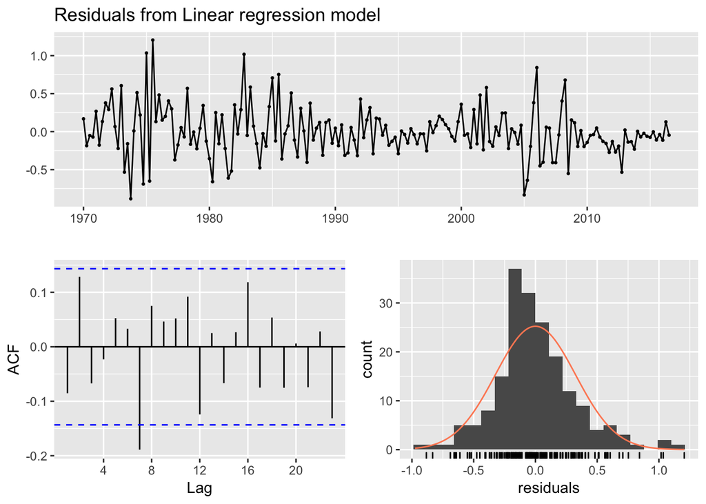

```
##
##  Breusch-Godfrey test for serial correlation of order up to 8
##
## data:  Residuals from Linear regression model
## LM test = 14.874, df = 8, p-value = 0.06163
```

```r
checkresiduals(fit_cons)
```

We can see that mean of the residuals could be close to zero but the residuals are varying with time that explains some autocorrelation. The histogram shows that the residuals seem to be slightly skewed, which may affect the coverage probability of the prediction intervals. The ACF plot shows one spike at lag 7 but p value is not signficant in B-G test. So, autocorrelation probably won’t effect the forecast much.

**Residual plots against predictors:-** If the underlying assumption of linear relationship between forecast and predictor variable is true then we expect residuals to be randomly scattered across the predictor variable. If the scatter plot shows a pattern then the relationship may ne non linear.

It is also necessary to plot the residuals against any predictors that are not in the model. If any of these show a pattern, then the corresponding predictor may need to be added to the model.

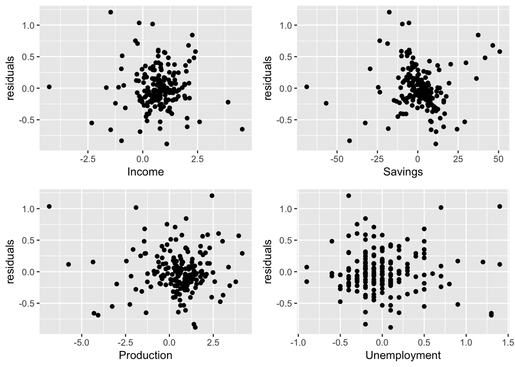

```r
library(gridExtra)
df = as.data.frame(uschange)
df[,"residuals"] = as.numeric(residuals(fit_cons))
p1 = ggplot(df, aes(x = Income, y = residuals)) +
  geom_point()
p2 = ggplot(df, aes(x = Savings, y = residuals)) +
  geom_point()
p3 = ggplot(df, aes(x = Production, y = residuals)) +
  geom_point()
p4 = ggplot(df, aes(x = Unemployment, y = residuals)) +
  geom_point()
gridExtra::grid.arrange(p1, p2, p3, p4, nrow = 2)
```

The residuals are looking randomly scattered.

**Residual plots against fitted values :-** A plot of the residuals against the fitted values should also show no pattern. If a pattern is observed, there may be heteroscedasticity in the errors which means that the variance of the residuals may not be constant. If this problem occurs, a transformation of the forecast variable such as a logarithm or square root may be required

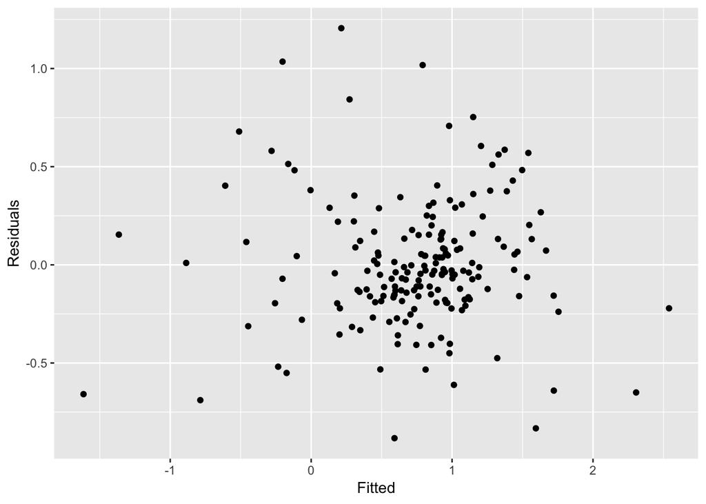

```r
cbind(Fitted = fitted(fit_cons),Residuals = residuals(fit_cons)) %>%
  as.data.frame() %>%
  ggplot(aes(x=Fitted, y= Residuals)) +
  geom_point()
```

Errors looks randomly scattered and so are homoscedastic.

**Outliers :-** Observations that take extreme values compared to the majority of the data are called outliers. We can identify outliers by looking at a scatter plot.

If outliers are incorrect data entry then we just simply remove them. Outliers occur when some observations are simply different. In this case it may not be wise for these observations to be removed. If an observation has been identified as a likely outlier, it is important to study it and analyse the possible reasons behind it.

Observations that have a large influence on the estimated coefficients of a regression model are called influential observations.Usually, influential observations are also outliers that are extreme in the x direction.

Confounding is not really a problem for forecasting, as we can still compute forecasts without needing to separate out the effects of the predictors. However, it becomes a problem with scenario forecasting as the scenarios should take account of the relationships between predictors. It is also a problem if some historical analysis of the contributions of various predictors is required.

**Multicollinearity :-** When similar information is provided by two or more of the predictor variables in a multiple regression. When two variables are correlated to each other, knowing the value of one variable tells you a lot about other variable.

Multicollinearity can also occur when a linear combination of predictors is highly correlated with another linear combination of predictors.

In case of perfect correlation, it is not possible to calculate the coefficients. When multicollinearity is present, the uncertainty associated with individual regression coefficients will be large. This is because they are difficult to estimate. Consequently, statistical tests (e.g., t-tests) on regression coefficients are unreliable. Also, it will not be possible to make accurate statements about the contribution of each separate predictor to the forecast.